# **Data Visualization**

## Python and R for Data Science

### Data Science and Management

[figure not shown]

# Package `matplotlib`

## `matplotlib`: installation

```python
! pip install matplotlib pandas numpy
```

## `matplotlib`: import

```python
import matplotlib.pyplot as plt
import pandas as pd
import numpy as np
```

## To visualize some data... we need the data

We can use `pandas` to load and process the data. For instance:

```python
url = "nutrients.csv" # "https://ercoppa.github.io/labds/04/nutrients.csv"
df = pd.read_csv(url)
df = df.set_index('Food')
df = df.sort_values(by='Carbs', ascending=True)
df
```

| Food | Measure | Grams | Calories | Protein | Fat | Sat.Fat | Fiber | Carbs | Category |
| --- | --- | --- | --- | --- | --- | --- | --- | --- | --- |
| Bacon | 2 slices | 16 | 95 | 4 | 8.00 | 7.00 | 0.0 | 1 | Meat, Poultry |
| Clams | 3 oz. | 85 | 87 | 12 | 1.00 | 0.00 | 0.0 | 2 | Fish, Seafood |
| Asparagus | 6 spears | 96 | 18 | 1 | 0.01 | 0.01 | 0.5 | 3 | Vegetables A-E |
| Cows' milk | 1 qt. | 976 | 660 | 32 | 40.00 | 36.00 | 0.0 | 48 | Dairy products |
| Butter | 1/2 cup | 112 | 113 | 114 | 115.00 | 116.00 | 117.0 | 118 | Fats, Oils, Shortenings |

## Anatomy of a `matplolib` figure

Example

Key elements

[figure not shown]

- Figure
- Axes
- Plot type: e.g., line
- Plot title
- Markers
- Grid
- Spine
- Legend
- Axes, {major,minor} ticks
- {x,y}label, {major,minor} tick label

## Figure, subplots, and Axes

### Figure

A figure contains zero or more subplots (also dubbed *Axes* in `matplotlib`).

It can be explicitly created with:

```python
fig = plt.figure()
```

In most cases, you may omit to explicitly create it since it will be implicitly generated when creating the subplots (see next slides).

More details at: [`matplotlib.figure`](https://matplotlib.org/stable/api/figure_api.html)

### Figure size

By default a figure is 640x480 pixels. However, we can set an arbitrary size:

```python
fig = plt.figure(figsize=(10, 5)) # figsize is (width, height) in inches
```

Alternatevely, we can set the figure's DPI ("dots-per-inch"):

```python
fig = plt.figure(dpi=300)
```

Setting the DPI will preserve the original ratio beetween width and height.

### Subplots and Axes

To create a figure with a **single** subplot (`Axes`):

```
Figure(640x480)
Axes(0.125,0.11;0.775x0.77)
```

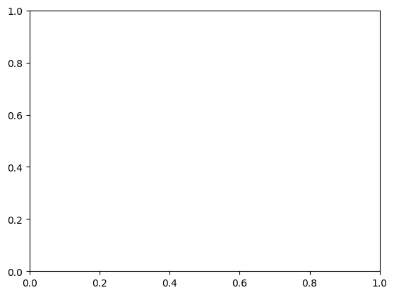

```python
fig, ax = plt.subplots()
print(fig)
print(ax)
```

Mere details at: [`matplotlib.pyplot.subplots`](https://matplotlib.org/stable/api/_as_gen/matplotlib.pyplot.subplots.html)

### Subplots and Axes (cont'd)

To create a figure with with **NxM** (e.g., N=3, M=2) subplots (`Axes`):

```
Figure(640x480)
[[<Axes: > <Axes: >]
 [<Axes: > <Axes: >]
 [<Axes: > <Axes: >]]
```

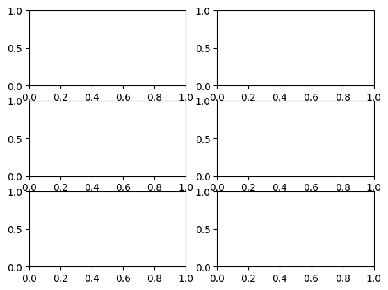

```python
fig, axs = plt.subplots(3, 2) # 3 rows, 2 columns
print(fig)
print(axs)
```

### Subplots and Axes: setting the figure size

When creating the figure from `subplots`, we can still set the figure size using the `figsize` or `dpi` arguments. E.g.:

```
Figure(768x576)
```

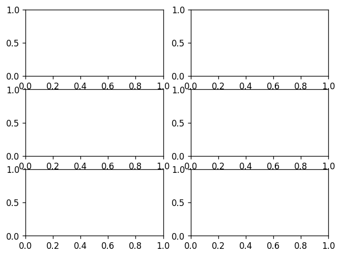

```python
fig, axs = plt.subplots(3, 2, dpi=120) # 3 rows, 2 columns
print(fig)
```

## Functional interface vs. Object-Oriented interface

When using `matplotlib` we have two approaches:

- **Object-Oriented interface (OO)**: given an `Axes`, we call methods over that `Axes` to modify its content. E.g., `ax.set_title("Title")`. **This is the approach that we will adopt**.
- **Functional interface**: we use functions from `pyplot`, which will modify the state of the *current* `Axes`. E.g., `plt.title("Title")`. This approach is problemetic, e.g., when we want to deal with multiple plots within the same figure since it is not clear which `Axes` we want to update. This approach was inspired by MATLAB.

For more details, see: https://matplotlib.org/matplotblog/posts/pyplot-vs-object-oriented-interface/

## Plot types

[figure not shown]

**[Gallery](https://matplotlib.org/stable/gallery/index.html)**

[figure not shown]

**[Gallery](https://matplotlib.org/stable/gallery/index.html)**

[figure not shown]

**[Gallery](https://matplotlib.org/stable/gallery/index.html)**

### Creating a specific plot type

Given an `Axes`, we can populate it with one or more plots using the methods of `Axes`:

### Line plot

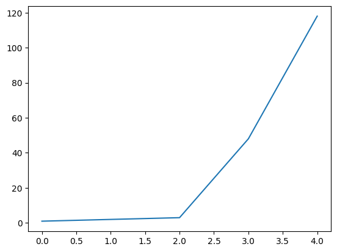

```python
fig, ax = plt.subplots()
points = ax.plot(range(df.index.size), df['Carbs'].values)
```

Mere details at: [`matplotlib.axes.Axes.plot`](https://matplotlib.org/stable/api/_as_gen/matplotlib.axes.Axes.plot.html)

### Scatter plot

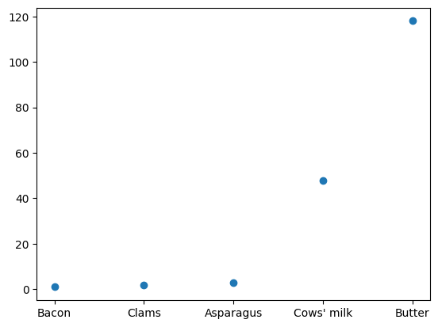

```python
fig, ax = plt.subplots()
points = ax.scatter(df.index, df.Carbs)
```

Mere details at: [`matplotlib.axes.Axes.scatter`](https://matplotlib.org/stable/api/_as_gen/matplotlib.axes.Axes.scatter.html)

### Horizontal bar plot

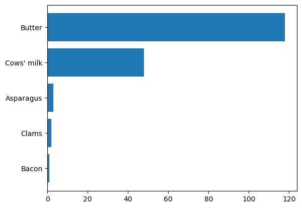

```python
fig, ax = plt.subplots()
bars = ax.barh(df.index, df.Carbs)
```

Mere details at: [`matplotlib.axes.Axes.barh`](https://matplotlib.org/stable/api/_as_gen/matplotlib.axes.Axes.barh.html)

### Vertical bar plot

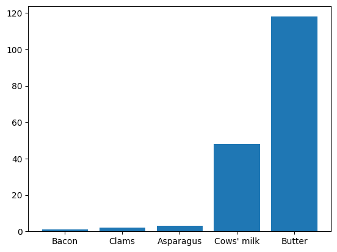

```python
fig, ax = plt.subplots()
bars = ax.bar(df.index, df.Carbs)
```

Mere details at: [`matplotlib.axes.Axes.bar`](https://matplotlib.org/stable/api/_as_gen/matplotlib.axes.Axes.bar.html)

### Stacked bar plot

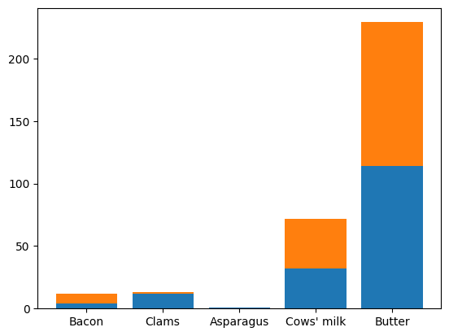

```python
fig, ax = plt.subplots()
bars = ax.bar(df.index, df["Protein"])
bars = ax.bar(df.index, df["Fat"], bottom=df["Protein"])
```

### Pie chart

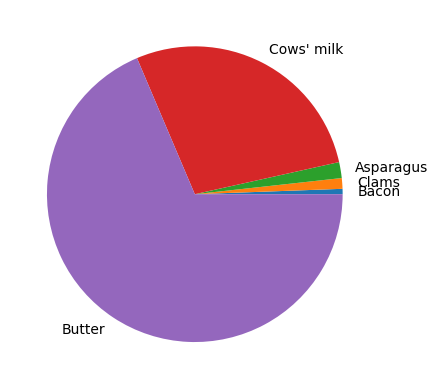

```python
fig, ax = plt.subplots()
slices = ax.pie(df.Carbs, labels=df.index)
```

Mere details at: [`matplotlib.axes.Axes.pie`](https://matplotlib.org/stable/api/_as_gen/matplotlib.axes.Axes.pie.html)

### Box plot

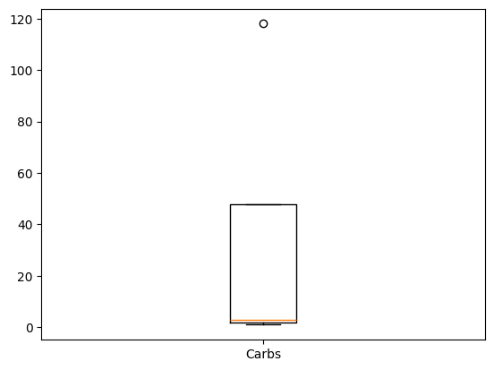

```python
fig, ax = plt.subplots()
slices = ax.boxplot(df.Carbs, tick_labels=["Carbs"]) # vert=False to make it horizontal
```

Mere details at: [`matplotlib.axes.Axes.boxplot`](https://matplotlib.org/stable/api/_as_gen/matplotlib.axes.Axes.boxplot.html)

### Violin plot

A popular alternative to a boxplot is:

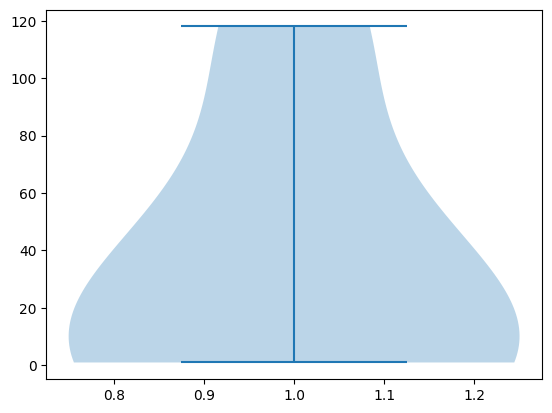

```python
fig, ax = plt.subplots()
slices = ax.violinplot(df.Carbs) # vert=False to make it horizontal
```

Mere details at: [`matplotlib.axes.Axes.violinplot`](https://matplotlib.org/stable/api/_as_gen/matplotlib.axes.Axes.violinplot.html)

### Histogram

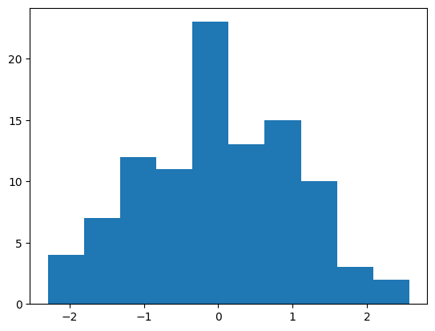

```python
fig, ax = plt.subplots()
data = np.random.standard_normal(100) # 100 random numbers
slices = ax.hist(data, bins=10)
```

Mere details at: [`matplotlib.axes.Axes.hist`](https://matplotlib.org/stable/api/_as_gen/matplotlib.axes.Axes.hist.html)

### Fill between

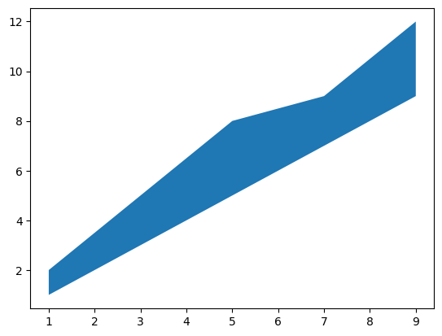

```python
x = [1, 3, 5, 7, 9]
y1 = [1, 3, 5, 7, 9]
y2 = [2, 5, 8, 9, 12]

fig, ax = plt.subplots()
lines = ax.fill_between(x, y1, y2)
```

Mere details at: [`matplotlib.axes.Axes.fill_between`](https://matplotlib.org/stable/api/_as_gen/matplotlib.axes.Axes.fill_between.html)

### Combining different plot types into an Axes

We can add more than one plot within the same `Axes`:

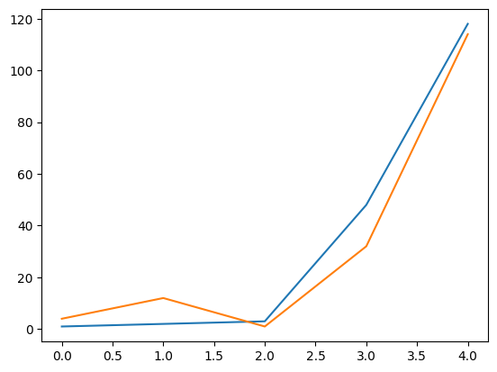

```python
fig, ax = plt.subplots()
line = ax.plot(range(df.index.size), df['Carbs'].values)
points = ax.plot(range(df.index.size), df['Protein'].values)
```

### Combining different plots types into the same figure

We can also add the plots in distincts axes:

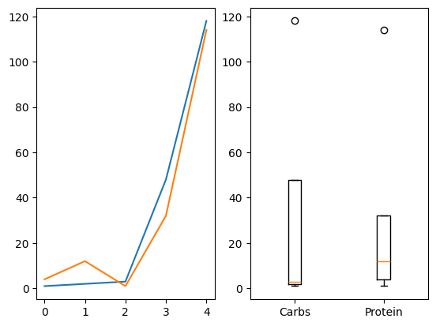

```python
fig, axes = plt.subplots(1, 2)
line = axes[0].plot(range(df.index.size), df['Carbs'].values)
points = axes[0].plot(range(df.index.size), df['Protein'].values)
slices = axes[1].boxplot([df.Carbs, df.Protein], tick_labels=["Carbs", "Protein"])
```

## Plot styling

### Pick a style

`matplotlib` ships with many styles that can drastically change the look of a plot, e.g., dark theme. Pick your favorite style from: [styles](https://matplotlib.org/stable/gallery/style_sheets/style_sheets_reference.html).

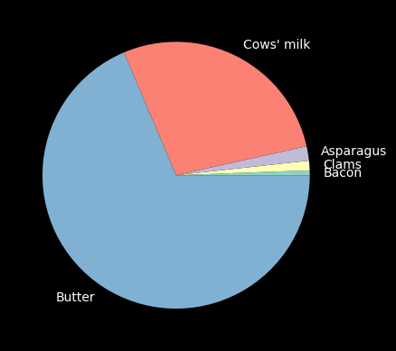

```python
plt.style.use('dark_background')
fig, ax = plt.subplots()
slices = ax.pie(df.Carbs, labels=df.index)
```

which is quite different from the `default` style:

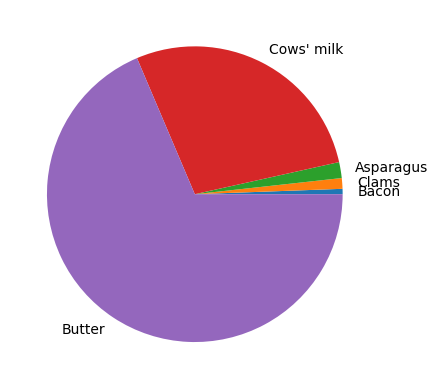

```python
plt.style.use('default')
fig, ax = plt.subplots()
slices = ax.pie(df.Carbs, labels=df.index)
```

See: [`matplotlib.style.use`](https://matplotlib.org/stable/api/style_api.html#matplotlib.style.use)

### Setting a title to the figure

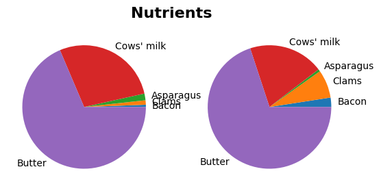

```python
fig, axes = plt.subplots(1, 2)
fig.suptitle("Nutrients", fontsize=16, fontweight='bold', y=0.80)
slices = axes[0].pie(df.Carbs, labels=df.index)
slices = axes[1].pie(df.Protein, labels=df.index)
```

See: [`matplotlib.figure.Figure.suptitle`](https://matplotlib.org/stable/api/_as_gen/matplotlib.figure.Figure.suptitle.html#matplotlib-figure-figure-suptitle)

### Setting a title to an Axes

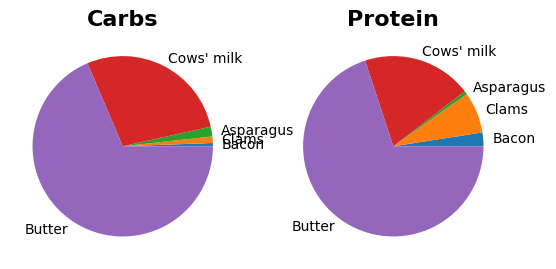

```python
fig, axes = plt.subplots(1, 2)
slices = axes[0].pie(df.Carbs, labels=df.index)
axes[0].set_title("Carbs", fontsize=16, fontweight='bold')
slices = axes[1].pie(df.Protein, labels=df.index)
axes[1].set_title("Protein", fontsize=16, fontweight='bold')
```

See: [`matplotlib.axes.Axes.set_title`](https://matplotlib.org/stable/api/_as_gen/matplotlib.axes.Axes.set_title.html)

### Setting x or y labels

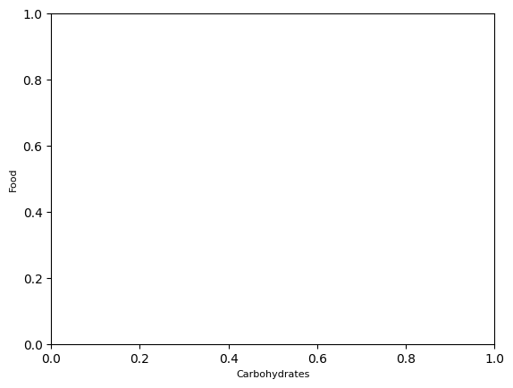

```python
fig, ax = plt.subplots()
ax.set_xlabel('Carbohydrates', fontsize = 8)
ax.set_ylabel('Food', fontsize = 8)
```

See: [`matplotlib.axes.Axes.set_xlabel`](https://matplotlib.org/stable/api/_as_gen/matplotlib.axes.Axes.set_xlabel.html) and [`matplotlib.axes.Axes.set_ylabel`](https://matplotlib.org/stable/api/_as_gen/matplotlib.axes.Axes.set_ylabel.html)

### Adding grid lines

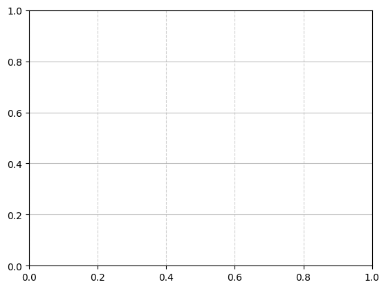

```python
fig, ax = plt.subplots()
ax.grid(axis='y', linestyle='-', alpha=0.8)
ax.grid(axis='x', linestyle='--', alpha=0.6)
```

See: [`matplotlib.axes.Axes.grid`](https://matplotlib.org/stable/api/_as_gen/matplotlib.axes.Axes.grid.html#)

### Rotate x or y ticks labels

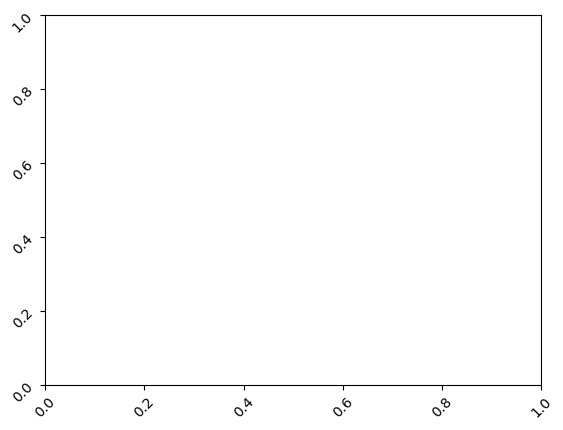

```python
fig, ax = plt.subplots()
ax.tick_params(axis='x', labelrotation=45)
ax.tick_params(axis='y', labelrotation=45)
```

See: [`matplotlib.axes.Axes.tick_params`](https://matplotlib.org/stable/api/_as_gen/matplotlib.axes.Axes.tick_params.html)

### Change color, size, and symbol of the markers in a scatter plot

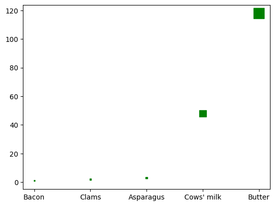

```python
fig, ax = plt.subplots()
points = ax.scatter(df.index, df.Carbs,
                color='green',
                marker='s',     #
                s=df.Carbs*2)   # make the size proportional to the value
```

See: [`matplotlib.markers`](https://matplotlib.org/stable/api/markers_api.html)

### Change color, size, marker, and style of a line in a plot

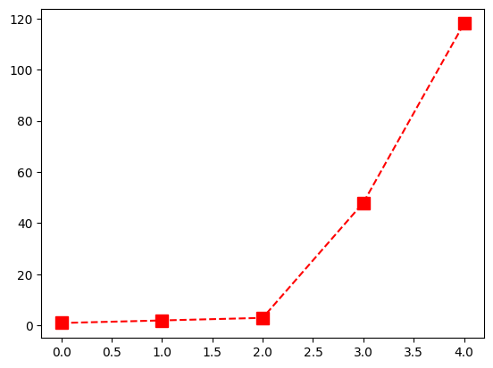

```python
fig, ax = plt.subplots()
points = ax.plot(range(df.index.size), df['Carbs'].values,
                color='red',
                linestyle='--',
                marker='s',
                markersize=10)
```

See: [`matplotlib.lines.Line2D`](https://matplotlib.org/stable/api/_as_gen/matplotlib.lines.Line2D.html#matplotlib.lines.Line2D) and [Linestyles](https://matplotlib.org/stable/gallery/lines_bars_and_markers/linestyles.html)

### Adding label on top of each bar

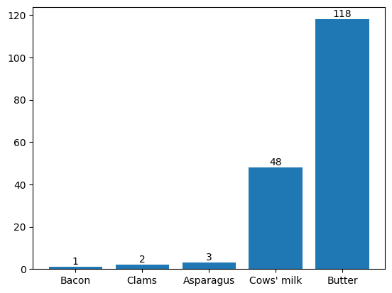

```python
fig, ax = plt.subplots()
bars = ax.bar(df.index, df.Carbs) # vertical bar plot
for bar in bars:
    yval = bar.get_height()
    ax.text(bar.get_x() + bar.get_width()/2, yval + 0.1, round(yval, 2), ha='center', va='bottom')
```

### Add percentage label in a pie chart

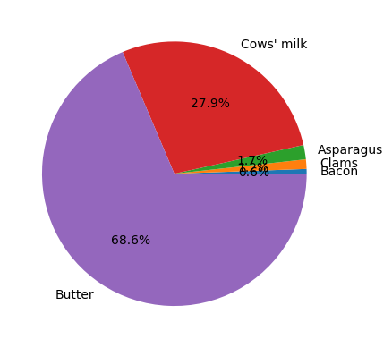

```python
fig, ax = plt.subplots()
slices = ax.pie(df.Carbs, labels=df.index, autopct='%1.1f%%')
```

### Add a legend

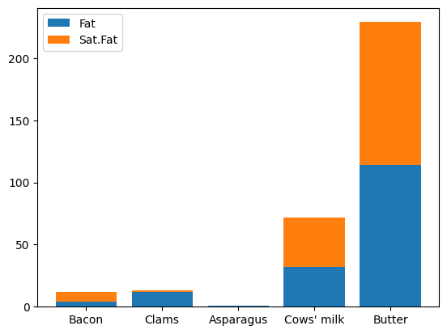

```python
fig, ax = plt.subplots()
bars = ax.bar(df.index, df["Protein"])
bars = ax.bar(df.index, df["Fat"], bottom=df["Protein"])
legend = ax.legend(df[["Fat", "Sat.Fat"]].columns)
```

### Change x and y limits

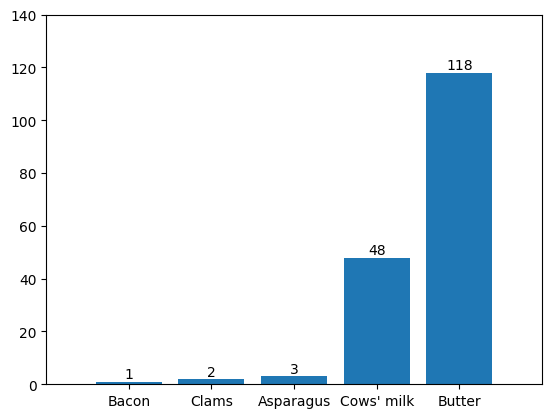

```python
fig, ax = plt.subplots()
bars = ax.bar(df.index, df.Carbs) # vertical bar plot
for bar in bars:
    ax.text(bar.get_x() + bar.get_width()/2, bar.get_height() + 0.1, round(bar.get_height(), 2), ha='center', va='bottom')
ax.set_xlim(-1, 5)
_ = ax.set_ylim(0, 140)
```

## Plot exporting (PNG, PDF)

## How to visualize a plot

While when working in a notebook any plot is automatically shown, **when writing a Python script**, we have to explitly decide when to show or export a figure.

If we want to visualize the plot in a seperate window:

```python
plt.show()
```

## How to save a plot

```python
fig, ax = plt.subplots()
bars = ax.bar(df.index, df["Protein"])
plt.savefig("file.png") # save in PNG
plt.savefig("file.pdf") # save in PDF
plt.close() # close the figure to avoid displaying it
```

## Documentation

- **User guide**: https://matplotlib.org/stable/users/index.html
- **API**: https://matplotlib.org/stable/api/index.html

# Package `seaborn`

## Why `seaborn`?

`matplotlib` is *extremely* powerful. However, it can be very tricky when aiming at some *advanced* plots. For instance, given a dataset, if we want to plot:

- a line that represents the average of the data points over a specific x
- the confidence interval for each data points over a specific x

[figure not shown]

In `matplotlib`, we have to:

- compute the average
- `plot` the line for the average
- compute the confindence interval
- plot the confidence intervals with, e.g., `fill_between`

## `seaborn`: `matplotlib` for the humans

`seaborn` is a data visualization library based on `matplotlib`. It provides a high-level interface for drawing *attractive* and **informative statistical** graphics.

[figure not shown]

It comes with convenient *shortcuts* to build several nice plots using `matplotlib`. Moreover, it naturally fits with `pandas` and `scikit-learn`.

## `seaborn`: installation

Install it with `pip3`:

```python
! pip install seaborn
```

## `seaborn`: installation

Import it:

```python
import seaborn as sns
```

## Some data to plot

In our examples, we reuse a few dummy datasets from `searbon`:

```python
tips = sns.load_dataset("tips")
tips
```

|  | total_bill | tip | sex | smoker | day | time | size |
| --- | --- | --- | --- | --- | --- | --- | --- |
| 0 | 16.99 | 1.01 | Female | No | Sun | Dinner | 2 |
| 1 | 10.34 | 1.66 | Male | No | Sun | Dinner | 3 |
| 2 | 21.01 | 3.50 | Male | No | Sun | Dinner | 3 |
| 3 | 23.68 | 3.31 | Male | No | Sun | Dinner | 2 |
| 4 | 24.59 | 3.61 | Female | No | Sun | Dinner | 4 |
| ... | ... | ... | ... | ... | ... | ... | ... |
| 239 | 29.03 | 5.92 | Male | No | Sat | Dinner | 3 |
| 240 | 27.18 | 2.00 | Female | Yes | Sat | Dinner | 2 |
| 241 | 22.67 | 2.00 | Male | Yes | Sat | Dinner | 2 |
| 242 | 17.82 | 1.75 | Male | No | Sat | Dinner | 2 |
| 243 | 18.78 | 3.00 | Female | No | Thur | Dinner | 2 |

244 rows × 7 columns